# Network Travel in Aarhus

This script is based on Luuk van der Meer’s presention from UseR2024 in Salzburg, travel along a network. https://luukvdmeer.github.io/UseR2024/notebook.html

```r
library(sfnetworks)
library(sf)
library(tidygraph)
library(tidyverse)
library(osmdata)
library(slopes)
library(raster)
library(units)
```

# 1. Get OpenStreetMap data

In this step, we use the osmdata package to retrieve data from OpenStreetMap. This package basically provides an R interface to the Overpass API of OpenStreetMap. First, we set the Den Gamle By and draw a circular buffer around it with a radius of 3km, which will serve as our area of interest.

```r
venue <- sf::st_sfc(sf::st_point(c(10.1934814423502, 56.1587545885577)), crs = 4326)
area <- sf::st_buffer(venue, units::set_units(3, "km"))
```

Now we query all streets within our area of interest from OpenStreetMap. In OpenStreetMap, streets are those features that have a value for the highway key. In R, they will be represented by an sf data frame with linestring geometries. Since some streets may be drawn as a closed polygon (like a square or a roundabout) we convert polygon borders into linestrings, before extracting only the linestrings from the API response. Finally, we cut streets at the edge of our area of interest and make sure all of them are single linestrings, meaning that the different parts of multi-linestrings will be seen as different street segments (note that to do this properly we first need to cast everything to multi-linestrings).

```r
streets <- osmdata::opq(sf::st_bbox(area)) %>%
    osmdata::add_osm_feature(key = "highway") %>%
    osmdata::osmdata_sf() %>%
    osmdata::osm_poly2line() %>%
    purrr::pluck("osm_lines") %>%
    sf::st_intersection(area) %>%
    sf::st_cast("MULTILINESTRING") %>%
    sf::st_cast("LINESTRING")
```

However, shelter locations do not yet exist in OSM, and so we will load our own points for public (BTG) and private (SR) shelters (safe rooms/ fortified rooms).

```r
# sikringsrum from BBR
SR <- st_read("../output_data/bbr_sikringsrum.geojson") %>%
    st_transform(crs = 4326)
# betondaekning grave from fieldrecording, kommunens data, and CDC records
BTG <- st_read("../output_data/done20241012.geojson")
```

Let us look at the result: a circle of lines with SR represented by red points

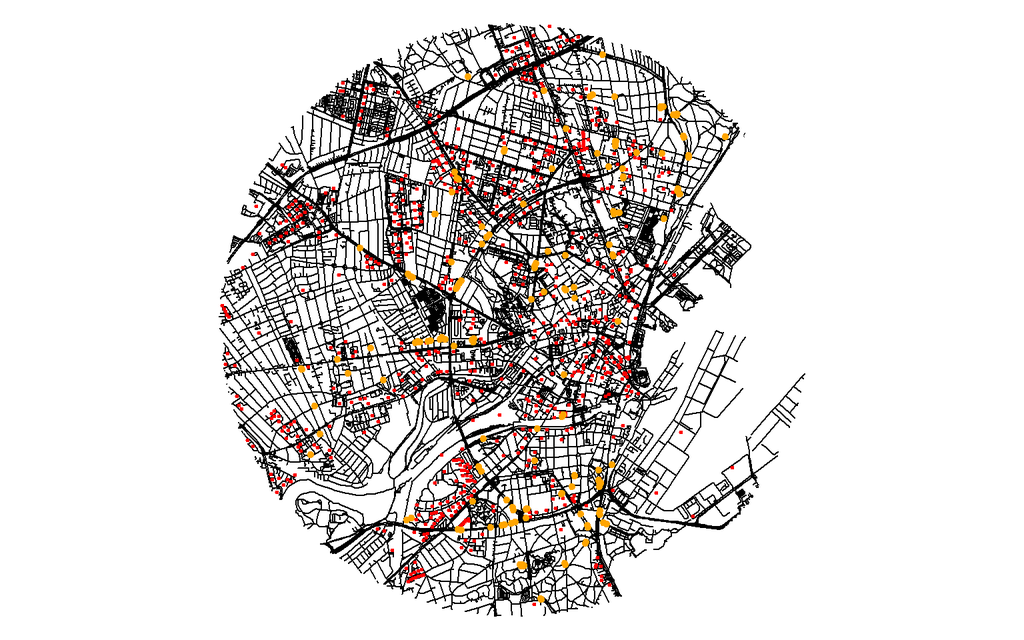

```r
par(mar = c(0, 0, 0, 0))
plot(sf::st_geometry(streets))
plot(sf::st_geometry(SR %>%
    st_intersection(area)), col = "red", pch = 20, cex = 0.5, add = TRUE)
plot(sf::st_geometry(BTG %>%
    st_intersection(area)), col = "orange", pch = 20, cex = 1, add = TRUE)
```